# Project 1: Can we predict who is likely to leave the bank?

# Train Model

Outcome variable of interest is binary. Logistic regression is used. Limited domain knowledge led to use of backwards elimination in model training. Since we will cross validate, we split data into train and test sets. We want to penalize model complexity so AIC minimization is sought.

```r
# Cross-validate by using 80% of data for training and 20% as new data
set.seed(1)
n <- dim(bankdata)[1]
rows <- sample(1:n, 0.8 * n)
bankdata_train <- bankdata[rows,]
bankdata_test <- bankdata[-rows,]
names(bankdata_train)
```

```
##  [1] "RowNumber"                          "CustomerId"
##  [3] "Surname"                            "CreditScore"
##  [5] "Geography"                          "Gender"
##  [7] "Age"                                "Tenure"
##  [9] "Balance"                            "NumOfProducts"
## [11] "HasCrCard"                          "IsActiveMember"
## [13] "EstimatedSalary"                    "Exited"
## [15] "Balance_cat"                        "NumOfProducts_cat"
## [17] "CreditScore_cat"                    "CreditScore_cat_fair"
## [19] "CreditScore_cat_good"               "CreditScore_cat_very_good"
## [21] "CreditScore_cat_exceptional"        "Balance_cat_greater_than_zero"
## [23] "Gender_Male"                        "Geography_Germany"
## [25] "Geography_Spain"                    "NumOfProducts_cat_greater_than_one"
```

```r
mod1 <- glm(Exited ~
              Age +
              Balance_cat_greater_than_zero +
              CreditScore_cat_fair +
              CreditScore_cat_good +
              CreditScore_cat_very_good +
              CreditScore_cat_exceptional +
              EstimatedSalary +
              Gender_Male +
              Geography_Germany +
              Geography_Spain +
              HasCrCard +
              IsActiveMember +
              NumOfProducts_cat_greater_than_one +
              Tenure +
              Balance_cat_greater_than_zero*Geography_Germany*Geography_Spain*NumOfProducts_cat_greater_than_one*Gender_Male +
              Age*Balance_cat_greater_than_zero +
              Age*Gender_Male +
              Age*Geography_Germany +
              Age*Geography_Spain +
              Age*HasCrCard +
              Age*IsActiveMember +
              Age*NumOfProducts_cat_greater_than_one +
              Tenure*IsActiveMember +
              Tenure*HasCrCard,
            family="binomial",data=bankdata_train)

# AIC: 6270.9
summary(mod1)
```

```
##
## Call:
## glm(formula = Exited ~ Age + Balance_cat_greater_than_zero +
##     CreditScore_cat_fair + CreditScore_cat_good + CreditScore_cat_very_good +
##     CreditScore_cat_exceptional + EstimatedSalary + Gender_Male +
##     Geography_Germany + Geography_Spain + HasCrCard + IsActiveMember +
##     NumOfProducts_cat_greater_than_one + Tenure + Balance_cat_greater_than_zero *
##     Geography_Germany * Geography_Spain * NumOfProducts_cat_greater_than_one *
##     Gender_Male + Age * Balance_cat_greater_than_zero + Age *
##     Gender_Male + Age * Geography_Germany + Age * Geography_Spain +
##     Age * HasCrCard + Age * IsActiveMember + Age * NumOfProducts_cat_greater_than_one +
##     Tenure * IsActiveMember + Tenure * HasCrCard, family = "binomial",
##     data = bankdata_train)
##
## Deviance Residuals:
##     Min       1Q   Median       3Q      Max
## -3.1028  -0.6046  -0.4018  -0.1864   3.1247
##
## Coefficients: (12 not defined because of singularities)
##                                                                                                                  Estimate
## (Intercept)                                                                                                    -5.534e+00
## Age                                                                                                             1.326e-01
## Balance_cat_greater_than_zero                                                                                  -6.846e-01
## CreditScore_cat_fair                                                                                           -1.148e-01
## CreditScore_cat_good                                                                                           -2.331e-01
## CreditScore_cat_very_good                                                                                      -1.181e-01
## CreditScore_cat_exceptional                                                                                    -1.325e-01
## EstimatedSalary                                                                                                 9.846e-07
## Gender_Male                                                                                                     6.536e-03
## Geography_Germany                                                                                               1.231e+00
## Geography_Spain                                                                                                 7.031e-01
## HasCrCard                                                                                                       3.158e-01
## IsActiveMember                                                                                                  2.760e+00
## NumOfProducts_cat_greater_than_one                                                                             -1.973e+00
## Tenure                                                                                                          1.601e-02
## Balance_cat_greater_than_zero:Geography_Germany                                                                        NA
## Balance_cat_greater_than_zero:Geography_Spain                                                                  -2.861e-01
## Geography_Germany:Geography_Spain                                                                                      NA
## Balance_cat_greater_than_zero:NumOfProducts_cat_greater_than_one                                                1.659e+00
## Geography_Germany:NumOfProducts_cat_greater_than_one                                                           -1.015e+00
```

[output cut: 229 more lines]

```
## Balance_cat_greater_than_zero:Gender_Male:Geography_Germany:Geography_Spain
## Balance_cat_greater_than_zero:Gender_Male:Geography_Germany:NumOfProducts_cat_greater_than_one
## Balance_cat_greater_than_zero:Gender_Male:Geography_Spain:NumOfProducts_cat_greater_than_one
## Gender_Male:Geography_Germany:Geography_Spain:NumOfProducts_cat_greater_than_one
## Balance_cat_greater_than_zero:Gender_Male:Geography_Germany:Geography_Spain:NumOfProducts_cat_greater_than_one
## ---
## Signif. codes:  0 '***' 0.001 '**' 0.01 '*' 0.05 '.' 0.1 ' ' 1
##
## (Dispersion parameter for binomial family taken to be 1)
##
##     Null deviance: 8045.1  on 7999  degrees of freedom
## Residual deviance: 6194.9  on 7962  degrees of freedom
## AIC: 6270.9
##
## Number of Fisher Scoring iterations: 6
```

```r
mod2 <- glm(Exited ~
              CreditScore_cat_good +
              EstimatedSalary +
              Balance_cat_greater_than_zero*Geography_Germany*NumOfProducts_cat_greater_than_one*Gender_Male +
              Age*IsActiveMember,
            family="binomial",data=bankdata_train)
# AIC: 6250.5
summary(mod2)
```

```
##
## Call:
## glm(formula = Exited ~ CreditScore_cat_good + EstimatedSalary +
##     Balance_cat_greater_than_zero * Geography_Germany * NumOfProducts_cat_greater_than_one *
##         Gender_Male + Age * IsActiveMember, family = "binomial",
##     data = bankdata_train)
##
## Deviance Residuals:
##     Min       1Q   Median       3Q      Max
## -3.1558  -0.6076  -0.4049  -0.1948   3.0811
##
## Coefficients: (4 not defined because of singularities)
##                                                                                                  Estimate
## (Intercept)                                                                                    -5.341e+00
## CreditScore_cat_good                                                                           -1.546e-01
## EstimatedSalary                                                                                 9.625e-07
## Balance_cat_greater_than_zero                                                                  -7.454e-01
## Geography_Germany                                                                               1.144e+00
## NumOfProducts_cat_greater_than_one                                                             -1.728e+00
## Gender_Male                                                                                    -1.470e-01
## Age                                                                                             1.283e-01
## IsActiveMember                                                                                  2.649e+00
## Balance_cat_greater_than_zero:Geography_Germany                                                        NA
## Balance_cat_greater_than_zero:NumOfProducts_cat_greater_than_one                                1.964e+00
## Geography_Germany:NumOfProducts_cat_greater_than_one                                           -1.268e+00
## Balance_cat_greater_than_zero:Gender_Male                                                      -3.849e-01
## Geography_Germany:Gender_Male                                                                   2.505e-01
## NumOfProducts_cat_greater_than_one:Gender_Male                                                 -7.914e-01
## Age:IsActiveMember                                                                             -8.822e-02
## Balance_cat_greater_than_zero:Geography_Germany:NumOfProducts_cat_greater_than_one                     NA
## Balance_cat_greater_than_zero:Geography_Germany:Gender_Male                                            NA
## Balance_cat_greater_than_zero:NumOfProducts_cat_greater_than_one:Gender_Male                    8.941e-01
## Geography_Germany:NumOfProducts_cat_greater_than_one:Gender_Male                               -2.608e-01
## Balance_cat_greater_than_zero:Geography_Germany:NumOfProducts_cat_greater_than_one:Gender_Male         NA
##                                                                                                Std. Error
## (Intercept)                                                                                     2.700e-01
## CreditScore_cat_good                                                                            7.726e-02
## EstimatedSalary                                                                                 5.623e-07
## Balance_cat_greater_than_zero                                                                   1.493e-01
## Geography_Germany                                                                               1.291e-01
```

[output cut: 77 more lines]

```
## Balance_cat_greater_than_zero:Geography_Germany:NumOfProducts_cat_greater_than_one
## Balance_cat_greater_than_zero:Geography_Germany:Gender_Male
## Balance_cat_greater_than_zero:NumOfProducts_cat_greater_than_one:Gender_Male                   **
## Geography_Germany:NumOfProducts_cat_greater_than_one:Gender_Male
## Balance_cat_greater_than_zero:Geography_Germany:NumOfProducts_cat_greater_than_one:Gender_Male
## ---
## Signif. codes:  0 '***' 0.001 '**' 0.01 '*' 0.05 '.' 0.1 ' ' 1
##
## (Dispersion parameter for binomial family taken to be 1)
##
##     Null deviance: 8045.1  on 7999  degrees of freedom
## Residual deviance: 6216.5  on 7983  degrees of freedom
## AIC: 6250.5
##
## Number of Fisher Scoring iterations: 6
```

```r
mod3 <- glm(Exited ~
              CreditScore_cat_good +
              EstimatedSalary +
              Geography_Germany*NumOfProducts_cat_greater_than_one+
              Balance_cat_greater_than_zero*NumOfProducts_cat_greater_than_one*Gender_Male+
              Age*IsActiveMember,
            family="binomial",data=bankdata_train)

summary(mod3)
```

```
##
## Call:
## glm(formula = Exited ~ CreditScore_cat_good + EstimatedSalary +
##     Geography_Germany * NumOfProducts_cat_greater_than_one +
##     Balance_cat_greater_than_zero * NumOfProducts_cat_greater_than_one *
##         Gender_Male + Age * IsActiveMember, family = "binomial",
##     data = bankdata_train)
##
## Deviance Residuals:
##     Min       1Q   Median       3Q      Max
## -3.1771  -0.6057  -0.4083  -0.1949   3.0807
##
## Coefficients:
##                                                                                Estimate
## (Intercept)                                                                  -5.337e+00
## CreditScore_cat_good                                                         -1.559e-01
## EstimatedSalary                                                               9.392e-07
## Geography_Germany                                                             1.269e+00
## NumOfProducts_cat_greater_than_one                                           -1.728e+00
## Balance_cat_greater_than_zero                                                -8.018e-01
## Gender_Male                                                                  -1.470e-01
## Age                                                                           1.282e-01
## IsActiveMember                                                                2.649e+00
## Geography_Germany:NumOfProducts_cat_greater_than_one                         -1.398e+00
## NumOfProducts_cat_greater_than_one:Balance_cat_greater_than_zero              2.023e+00
## Balance_cat_greater_than_zero:Gender_Male                                    -2.746e-01
## NumOfProducts_cat_greater_than_one:Gender_Male                               -7.913e-01
## Age:IsActiveMember                                                           -8.817e-02
## NumOfProducts_cat_greater_than_one:Balance_cat_greater_than_zero:Gender_Male  7.784e-01
##                                                                              Std. Error
## (Intercept)                                                                   2.699e-01
## CreditScore_cat_good                                                          7.727e-02
## EstimatedSalary                                                               5.621e-07
## Geography_Germany                                                             9.153e-02
## NumOfProducts_cat_greater_than_one                                            1.707e-01
## Balance_cat_greater_than_zero                                                 1.441e-01
## Gender_Male                                                                   1.716e-01
## Age                                                                           5.699e-03
## IsActiveMember                                                                2.895e-01
## Geography_Germany:NumOfProducts_cat_greater_than_one                          1.594e-01
```

[output cut: 48 more lines]

```
## NumOfProducts_cat_greater_than_one:Balance_cat_greater_than_zero             ***
## Balance_cat_greater_than_zero:Gender_Male
## NumOfProducts_cat_greater_than_one:Gender_Male                               **
## Age:IsActiveMember                                                           ***
## NumOfProducts_cat_greater_than_one:Balance_cat_greater_than_zero:Gender_Male *
## ---
## Signif. codes:  0 '***' 0.001 '**' 0.01 '*' 0.05 '.' 0.1 ' ' 1
##
## (Dispersion parameter for binomial family taken to be 1)
##
##     Null deviance: 8045.1  on 7999  degrees of freedom
## Residual deviance: 6218.3  on 7985  degrees of freedom
## AIC: 6248.3
##
## Number of Fisher Scoring iterations: 6
```

```r
# AIC 6248



mod4 <- glm(Exited ~
              CreditScore_cat_good +
              EstimatedSalary +
              Geography_Germany*NumOfProducts_cat_greater_than_one +
              Balance_cat_greater_than_zero*NumOfProducts_cat_greater_than_one +
              NumOfProducts_cat_greater_than_one*Gender_Male +
              Age*IsActiveMember,
            family="binomial",data=bankdata_train)

# AIC 6251
summary(mod4)
```

```
##
## Call:
## glm(formula = Exited ~ CreditScore_cat_good + EstimatedSalary +
##     Geography_Germany * NumOfProducts_cat_greater_than_one +
##     Balance_cat_greater_than_zero * NumOfProducts_cat_greater_than_one +
##     NumOfProducts_cat_greater_than_one * Gender_Male + Age *
##     IsActiveMember, family = "binomial", data = bankdata_train)
##
## Deviance Residuals:
##     Min       1Q   Median       3Q      Max
## -3.1621  -0.6041  -0.4050  -0.2135   3.0109
##
## Coefficients:
##                                                                    Estimate
## (Intercept)                                                      -5.215e+00
## CreditScore_cat_good                                             -1.518e-01
## EstimatedSalary                                                   9.476e-07
## Geography_Germany                                                 1.271e+00
## NumOfProducts_cat_greater_than_one                               -1.974e+00
## Balance_cat_greater_than_zero                                    -9.399e-01
## Gender_Male                                                      -3.617e-01
## Age                                                               1.278e-01
## IsActiveMember                                                    2.639e+00
## Geography_Germany:NumOfProducts_cat_greater_than_one             -1.400e+00
## NumOfProducts_cat_greater_than_one:Balance_cat_greater_than_zero  2.374e+00
## NumOfProducts_cat_greater_than_one:Gender_Male                   -2.302e-01
## Age:IsActiveMember                                               -8.785e-02
##                                                                  Std. Error
## (Intercept)                                                       2.576e-01
## CreditScore_cat_good                                              7.726e-02
## EstimatedSalary                                                   5.620e-07
## Geography_Germany                                                 9.141e-02
## NumOfProducts_cat_greater_than_one                                1.419e-01
## Balance_cat_greater_than_zero                                     1.052e-01
## Gender_Male                                                       8.020e-02
## Age                                                               5.693e-03
## IsActiveMember                                                    2.893e-01
## Geography_Germany:NumOfProducts_cat_greater_than_one              1.597e-01
## NumOfProducts_cat_greater_than_one:Balance_cat_greater_than_zero  1.700e-01
## NumOfProducts_cat_greater_than_one:Gender_Male                    1.346e-01
```

[output cut: 24 more lines]

```
## IsActiveMember                                                    < 2e-16 ***
## Geography_Germany:NumOfProducts_cat_greater_than_one              < 2e-16 ***
## NumOfProducts_cat_greater_than_one:Balance_cat_greater_than_zero  < 2e-16 ***
## NumOfProducts_cat_greater_than_one:Gender_Male                     0.0871 .
## Age:IsActiveMember                                                < 2e-16 ***
## ---
## Signif. codes:  0 '***' 0.001 '**' 0.01 '*' 0.05 '.' 0.1 ' ' 1
##
## (Dispersion parameter for binomial family taken to be 1)
##
##     Null deviance: 8045.1  on 7999  degrees of freedom
## Residual deviance: 6225.0  on 7987  degrees of freedom
## AIC: 6251
##
## Number of Fisher Scoring iterations: 5
```

```r
mod5 <- glm(Exited ~
              CreditScore_cat_good +
              Gender_Male +
              Geography_Germany*NumOfProducts_cat_greater_than_one +
              Balance_cat_greater_than_zero*NumOfProducts_cat_greater_than_one +
              Age*IsActiveMember,
            family="binomial",data=bankdata_train)

# AIC: 6252.6
summary(mod5)
```

```
##
## Call:
## glm(formula = Exited ~ CreditScore_cat_good + Gender_Male + Geography_Germany *
##     NumOfProducts_cat_greater_than_one + Balance_cat_greater_than_zero *
##     NumOfProducts_cat_greater_than_one + Age * IsActiveMember,
##     family = "binomial", data = bankdata_train)
##
## Deviance Residuals:
##     Min       1Q   Median       3Q      Max
## -3.1937  -0.6007  -0.4067  -0.2188   2.9704
##
## Coefficients:
##                                                                   Estimate
## (Intercept)                                                      -5.078092
## CreditScore_cat_good                                             -0.151139
## Gender_Male                                                      -0.445165
## Geography_Germany                                                 1.269640
## NumOfProducts_cat_greater_than_one                               -2.078851
## Balance_cat_greater_than_zero                                    -0.935187
## Age                                                               0.127758
## IsActiveMember                                                    2.635053
## Geography_Germany:NumOfProducts_cat_greater_than_one             -1.400770
## NumOfProducts_cat_greater_than_one:Balance_cat_greater_than_zero  2.369287
## Age:IsActiveMember                                               -0.087819
##                                                                  Std. Error
## (Intercept)                                                        0.249538
## CreditScore_cat_good                                               0.077241
## Gender_Male                                                        0.064311
## Geography_Germany                                                  0.091473
## NumOfProducts_cat_greater_than_one                                 0.128058
## Balance_cat_greater_than_zero                                      0.105301
## Age                                                                0.005692
## IsActiveMember                                                     0.289302
## Geography_Germany:NumOfProducts_cat_greater_than_one               0.159341
## NumOfProducts_cat_greater_than_one:Balance_cat_greater_than_zero   0.169755
## Age:IsActiveMember                                                 0.006827
##                                                                  z value
## (Intercept)                                                      -20.350
## CreditScore_cat_good                                              -1.957
## Gender_Male                                                       -6.922
```

[output cut: 15 more lines]

```
## Age                                                               < 2e-16 ***
## IsActiveMember                                                    < 2e-16 ***
## Geography_Germany:NumOfProducts_cat_greater_than_one              < 2e-16 ***
## NumOfProducts_cat_greater_than_one:Balance_cat_greater_than_zero  < 2e-16 ***
## Age:IsActiveMember                                                < 2e-16 ***
## ---
## Signif. codes:  0 '***' 0.001 '**' 0.01 '*' 0.05 '.' 0.1 ' ' 1
##
## (Dispersion parameter for binomial family taken to be 1)
##
##     Null deviance: 8045.1  on 7999  degrees of freedom
## Residual deviance: 6230.6  on 7989  degrees of freedom
## AIC: 6252.6
##
## Number of Fisher Scoring iterations: 5
```

# Model interaction plots

Strong interaction between Balance category and Number of product category. This is expected considering having a balance implies having at least one product. Strong interaction between Age numerical variable and category Is Active and whether customer exits Weak interaction between number of products and whether customer is in France or Spain and whether customer exits. AIC increases from 6252.6 to 6327.4 with removal of this last interaction term, so we will keep it in.

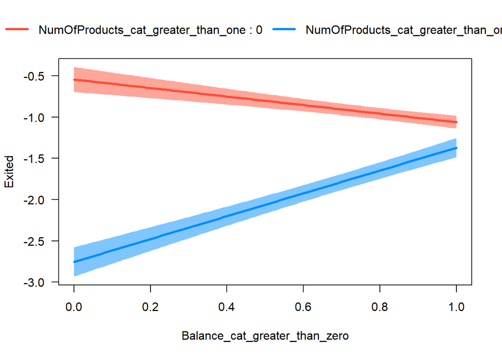

```r
# interaction plot
i1 <- glm(Exited ~ Balance_cat_greater_than_zero * NumOfProducts_cat_greater_than_one,
          data = bankdata_train, family="binomial")
visreg(i1, "Balance_cat_greater_than_zero", by = "NumOfProducts_cat_greater_than_one",
       overlay = TRUE, partial = FALSE, rug = FALSE, ylab="Exited")
```

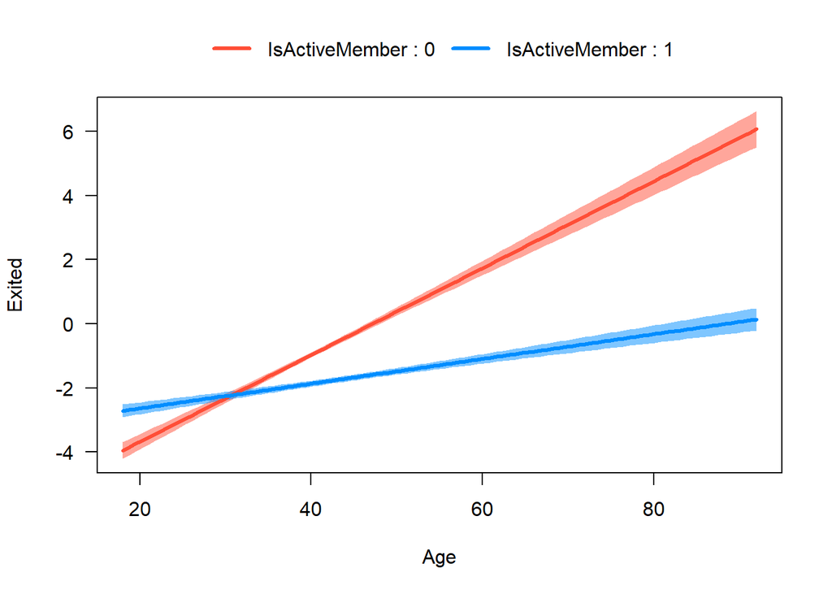

```r
i2 <- glm(Exited ~ Age * IsActiveMember,
          data = bankdata_train, family="binomial")
visreg(i2, "Age", by = "IsActiveMember",
       overlay = TRUE, partial = FALSE, rug = FALSE, ylab="Exited")
```

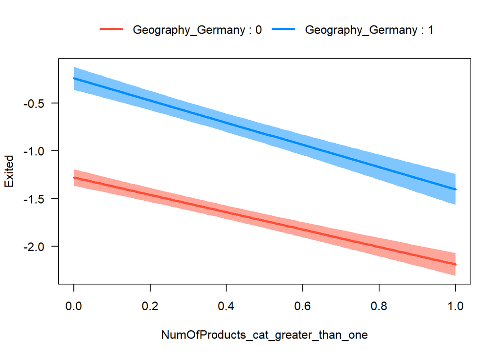

```r
# the change in the difference in log odds as the number of products goes from one to more than one is subtle
i3 <- glm(Exited ~ NumOfProducts_cat_greater_than_one * Geography_Germany,
          data = bankdata_train, family="binomial")
visreg(i3, "NumOfProducts_cat_greater_than_one", by = "Geography_Germany",
       overlay = TRUE, partial = FALSE, rug = FALSE,ylab="Exited")
```